# Preprocessing danych

```python
import pandas as pd
import numpy as np
import seaborn as sns
import matplotlib.pyplot as plt
from sklearn import preprocessing
import re
import math
```

```python
data = pd.read_csv("diabetic_data.csv")
data.head()
```

|  | encounter_id | patient_nbr | race | gender | age | weight | admission_type_id | discharge_disposition_id | admission_source_id | time_in_hospital | ... | citoglipton | insulin | glyburide-metformin | glipizide-metformin | glimepiride-pioglitazone | metformin-rosiglitazone | metformin-pioglitazone | change | diabetesMed | readmitted |
| --- | --- | --- | --- | --- | --- | --- | --- | --- | --- | --- | --- | --- | --- | --- | --- | --- | --- | --- | --- | --- | --- |
| 0 | 2278392 | 8222157 | Caucasian | Female | [0-10) | ? | 6 | 25 | 1 | 1 | ... | No | No | No | No | No | No | No | No | No | NO |
| 1 | 149190 | 55629189 | Caucasian | Female | [10-20) | ? | 1 | 1 | 7 | 3 | ... | No | Up | No | No | No | No | No | Ch | Yes | >30 |
| 2 | 64410 | 86047875 | AfricanAmerican | Female | [20-30) | ? | 1 | 1 | 7 | 2 | ... | No | No | No | No | No | No | No | No | Yes | NO |
| 3 | 500364 | 82442376 | Caucasian | Male | [30-40) | ? | 1 | 1 | 7 | 2 | ... | No | Up | No | No | No | No | No | Ch | Yes | NO |
| 4 | 16680 | 42519267 | Caucasian | Male | [40-50) | ? | 1 | 1 | 7 | 1 | ... | No | Steady | No | No | No | No | No | Ch | Yes | NO |

5 rows × 50 columns

# Identyfikacja zmiennej objaśnianej

Za pomocą tego data setu chcemy przewidzieć, czy pacjent powróci do szpitala po zwolnieniu go z niego (etykieta `readmitted`). Możemy więc od razu wykluczyć pewne kolumny, które to na pewno nie są z tym związane.

- `encounter_id` - to unikalna wartość dla każdego przyjęia do szpitala, nie ma związku z jakimikolwiek czynnikami chorobowymi, można więc usunąć te kolumnę, by uniknąć potencjalnego przeuczenia
- `patient_nbr` - jest indywidualna dla każdego pacjenta, więc zostawienie jej ponownie mogłoby prowadzić do przeuczenia

Pozostałe kolumny są już mniej lub bardziej związane z czynnikami chorobowymi (przyjmowane substancje leczące, rodzaj diagnozy, itd.), więc mogą decydować o readmisji danego pacjenta. Dokładny opis poszczególnych kolumn można znaleźć pod linkiem: https://www.hindawi.com/journals/bmri/2014/781670/tab1/ dlatego nie będę już przepisywał tych opisów do raportu

# Typy kolumn

```python
data.info()
```

```
<class 'pandas.core.frame.DataFrame'>
RangeIndex: 101766 entries, 0 to 101765
Data columns (total 50 columns):
 #   Column                    Non-Null Count   Dtype
---  ------                    --------------   -----
 0   encounter_id              101766 non-null  int64
 1   patient_nbr               101766 non-null  int64
 2   race                      101766 non-null  object
 3   gender                    101766 non-null  object
 4   age                       101766 non-null  object
 5   weight                    101766 non-null  object
 6   admission_type_id         101766 non-null  int64
 7   discharge_disposition_id  101766 non-null  int64
 8   admission_source_id       101766 non-null  int64
 9   time_in_hospital          101766 non-null  int64
```

[output cut: 42 more lines]

# Identyfikacja brakujących danych i imputacja

```python
data.drop('encounter_id', axis = 1, inplace = True)
data.drop('patient_nbr', axis = 1, inplace = True)
```

Sprawdźmy, czy któreś inne kolumny nie powinny zostać usunięte z jakichś powodów

```python
per = data["weight"][data["weight"] == "?"].count()/data["weight"].count()*100
print(f"Ilość '?' w kolumnie weight: {per:.{2}f}%")
```

```
Ilość '?' w kolumnie weight: 96.86%
```

Widać stąd, że kolumnę `weight` można bez problemu usunąć, gdyż braki danych "?" stanowią aż ponad 96% wszystkich danych

```python
data.drop('weight', axis = 1, inplace = True)
```

```python
print(data["medical_specialty"][data["medical_specialty"] == "?"].count()/data["medical_specialty"].count())
data.drop('medical_specialty', axis = 1, inplace = True)
```

```
0.49082208203132677
```

Usuwam kolummnę `medical_speciality`, ponieważ ma aż prawie 50% braków.

```python
print(data["payer_code"][data["payer_code"] == "?"].count()/data["payer_code"].count())
data.drop('payer_code', axis = 1, inplace = True)
```

```
0.395574160328597
```

Usuwam kolummnę `payer_code`, bo kod nie ma zbyt wiele wspólnego ze zmienną `readmitted`, a braki danych stanowią aż prawie 40%

Pod linkiem wymienionym w Identyfikacji zmiennej objaśnianej możemy zobaczyć, że w kolumnach `Race` i `diag_3` jest odpowiednio 2% i 1% braków danych. Jako, że to naprawdę niewiele danych możemy po prostu usunąć te wiersze, w których wystąpi brak danych w tych kolumnach. To samo w kolumnach `diag_1` i `diag_2`, w których również występują braki danych w postaci "?" i również jest ich naprawdę mało.

```python
data = data.drop(data[data.race == "?"].index)
data = data.drop(data[data.diag_3 == "?"].index)
data = data.drop(data[data.diag_1 == "?"].index)
data = data.drop(data[data.diag_2 == "?"].index)
```

Ponadto usuńmy rekordy, w których płeć ma wartość inną niż `Female`/`Male`, ponieważ jest ich bardzo mało, a konkretnie

```python
data["gender"].value_counts()
```

```
Female             52833
Male               45219
Unknown/Invalid        1
Name: gender, dtype: int64
```

```python
data = data.drop(data[data.gender == "Unknown/Invalid"].index)
```

```python
data.drop(["citoglipton", "examide", "metformin-rosiglitazone"], axis = 1, inplace = True)
```

# Encoding zmiennych kategorycznych

Wpierw możemy encodować kolumny z substancjami medycznymi przyjmowanymi przez pacjentów.

```python
le = preprocessing.LabelEncoder()
le.fit(data["insulin"])
print(f"Wartości w tych kolumnach to: {list(le.classes_)}")
```

```
Wartości w tych kolumnach to: ['Down', 'No', 'Steady', 'Up']
```

Jako, że w tych kolumnach występują jedynie 4 różne wartości, w tym `No` oznacza, że pacjent w ogóle nie przyjmuje danej substancji, natomiast pozostałe wartości to różne warianty przyjmowania (`Down` - przyjmuje mniej, `Steady` - przyjmuje tyle samo, `Up` - przyjmuje więcej). Możemy więc zastosować kodowanie, gdzie 0 będzie sytuacja, gdy pacjent w ogóle nie przyjmuje leku, a 1 gdy przyjmuje.

```python
dict = {"No" : 0, "Down" : 1, "Steady" : 1, "Up" : 1}
for i in range(19, 39):
    data.iloc[:, i] = data.iloc[:, i].map(dict)
```

Ponadto możemy to również zrobić dla kolumn `gender`, `change`, oraz `diabetesMed`, gdyż są to kolumny binarne.

```python
names = ["gender", "change", "diabetesMed"]
for i in names:
    le2 = preprocessing.LabelEncoder()
    le2.fit(data[i])
    data[i] = le2.transform(data[i])
```

```python
names = ["race", "A1Cresult", "admission_type_id", "num_procedures", "max_glu_serum"]
for i in names:
    cols = pd.get_dummies(data[i], prefix=i)
    data.drop(i, axis = 1, inplace = True)
    data = data.join(cols)
```

```python
data["readmitted"].unique()
```

```
array(['>30', 'NO', '<30'], dtype=object)
```

```python
dict = {"NO" : 0, "<30" : 1, ">30" : 2}
data["readmitted"] = data["readmitted"].map(dict)
```

# Transformacje danych

Możemy przetransformować niektóre kolumny zawierające wiele wartości liczbowych poprzez zgrupowanie tych wartości przedziałami. Zrobimy to po kolei na kolumnach `time_in_hospital`, `number_outpatient`

Nie potrzeba nam raczej informacji o dokładnej ilości dni tylko wystarczy, aby to była ogólna informacja o długości pobytu, pogrupujmy więc wartości od 0 do 14 na grupy `short - 0`, `medium - 1` i `long - 2`.

```python
data["time_in_hospital"] = pd.cut(data["time_in_hospital"], bins = [0., 4, 9, np.inf], labels = [0, 1, 2])
```

Dla kolumn `number_outpatient`, `number_emergency` i `number_inpatient` wartości powyżej 10 występują po naprawdę niewiele razy w stosunku do tych od 0 do 10, więc możemy zastąpić je wartością 10.

```python
data.loc[data["number_outpatient"] >= 10, "number_outpatient"] = 10
data.loc[data["number_emergency"] >= 10, "number_emergency"] = 10
data.loc[data["number_inpatient"] >= 10, "number_inpatient"] =10
```

Przekształćmy kolumnę age na wartości numeryczne. Skoro mamy podane przedziały wieku możemy bez straty ogólności przekształcić je na środki tych przedziałów

```python
def extract_and_get_mean(x):
    values = re.findall(r'\d+', x)
    return (int(values[0]) + int(values[1]))/2
```

```python
data["age"] = data["age"].apply(extract_and_get_mean)
```

```python
data = data.astype({"time_in_hospital" : int, "age" : int})
```

Dodatkowo możemy pogrupować wartości diagnoz z grupy pierwszej (diagnoza główna) według ich grup omówionych pod linkiem: https://www.hindawi.com/journals/bmri/2014/781670/tab2/ . Natomiast kolumny `diag_2` i `diag_3` usunę, gdyż są to diagnozy dodatkowe, tak więc najważniejsze wartości zawiera kolumna `diag_1`.

```python
alfabet = ['a', 'b', 'c', 'd', 'e', 'f', 'g', 'h', 'i', 'j', 'k', 'l', 'm', 'n', 'o', 'p', 'q', 'r', 's', 't', 'u', 'v', 'w', 'x', 'y', 'z']
```

```python
def group_diagnoses(x):
    if (x[0].lower() in alfabet or (280 < math.floor(float(x)) < 289) or (320 < math.floor(float(x)) < 329) or (630 < math.floor(float(x)) < 679) or (360 < math.floor(float(x)) < 389) or (740 < math.floor(float(x)) < 749)):
        return "Other"
    elif (390 < math.floor(float(x)) < 459 or math.floor(float(x)) == 785):
        return  "Circulatory"
    elif (460 < math.floor(float(x)) < 519 or math.floor(float(x)) == 786):
        return  "Respiratory"
    elif (520 < math.floor(float(x)) < 579 or math.floor(float(x)) == 787):
        return "Digestive"
    elif (800 < math.floor(float(x)) < 999):
        return "Injury"
    elif (710 < math.floor(float(x)) < 739):
        return "Musculoskeletal"
    elif (580 < math.floor(float(x)) < 629 or math.floor(float(x)) == 788):
        return  "Genitourinary"
    elif (math.floor(float(x)) == 250):
        return  "Diabetes"
    else:
        return "Neoplasms"
```

```python
data["diag_1"] = data["diag_1"].apply(group_diagnoses)
```

```python
data.drop('diag_2', axis = 1, inplace = True)
data.drop('diag_3', axis = 1, inplace = True)
```

Na koniec zastosujmy One hot encoding do kolumny `diag_1`, gdyż zawiera ona tylko 9 unikalnych wartości.

```python
cols = pd.get_dummies(data["diag_1"], prefix="diag_1")
data.drop("diag_1", axis = 1, inplace = True)
data = data.join(cols)
```

# Eksploracyjna analiza danych

Sprawdźmy ponownie typy danych

```python
data.info()
```

```
<class 'pandas.core.frame.DataFrame'>
Int64Index: 98052 entries, 1 to 101765
Data columns (total 71 columns):
 #   Column                    Non-Null Count  Dtype
---  ------                    --------------  -----
 0   gender                    98052 non-null  int32
 1   age                       98052 non-null  int32
 2   discharge_disposition_id  98052 non-null  int64
 3   admission_source_id       98052 non-null  int64
 4   time_in_hospital          98052 non-null  int32
 5   num_lab_procedures        98052 non-null  int64
 6   num_medications           98052 non-null  int64
 7   number_outpatient         98052 non-null  int64
 8   number_emergency          98052 non-null  int64
 9   number_inpatient          98052 non-null  int64
```

[output cut: 63 more lines]

## Analiza jednowymiarowa

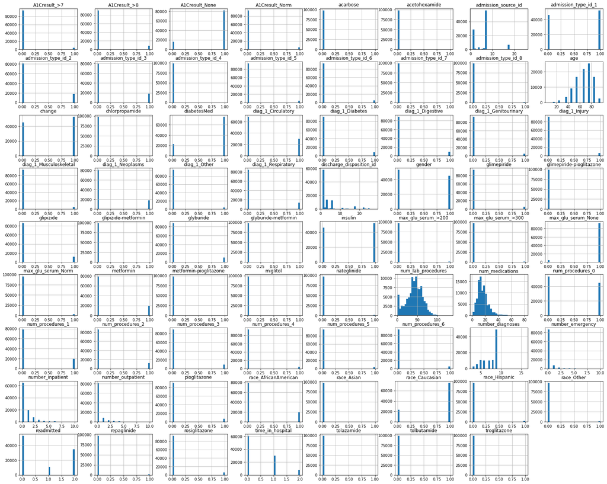

```python
data.hist(bins= 30,figsize = (28, 23))
plt.show()
```

Stwórzmy `describe` dla danych przyjmujących więcej niż 5 różnych wartości gdyż tylko wtedy ma to większy sens

```python
data.iloc[:, [1, 5, 6, 8, 9, 10]].describe()
```

|  | age | num_lab_procedures | num_medications | number_emergency | number_inpatient | number_diagnoses |
| --- | --- | --- | --- | --- | --- | --- |
| count | 98052.000000 | 98052.000000 | 98052.000000 | 98052.000000 | 98052.000000 | 98052.000000 |
| mean | 66.260250 | 43.148462 | 16.119590 | 0.194978 | 0.643597 | 7.512096 |
| std | 15.590805 | 19.711757 | 8.108496 | 0.740604 | 1.241586 | 1.832472 |
| min | 5.000000 | 1.000000 | 1.000000 | 0.000000 | 0.000000 | 3.000000 |
| 25% | 55.000000 | 31.000000 | 11.000000 | 0.000000 | 0.000000 | 6.000000 |
| 50% | 65.000000 | 44.000000 | 15.000000 | 0.000000 | 0.000000 | 8.000000 |
| 75% | 75.000000 | 57.000000 | 20.000000 | 0.000000 | 1.000000 | 9.000000 |
| max | 95.000000 | 132.000000 | 81.000000 | 10.000000 | 10.000000 | 16.000000 |

### Wnioski z analizy jednowymiarowej

- większość zmiennych przyjmuje bardzo ograniczoną ilość wartości
- większość pacjentów w ogóle nie przyjmuje leków wymienionych w tym secie danych
- kolumny `age`, `num_lab_procedures` i `num_medications` dane są rozkładem poodobnym do normalnego (skośny), najprawdopodobniej mozna by je przekształcić do rozkładu o wiele bardziej podobnego do normalnego za pomocą logarytmowania

## Analiza wielowymiarowa

Stworzymy macierz korelacji, ale na danych sprzed one hot encodingu

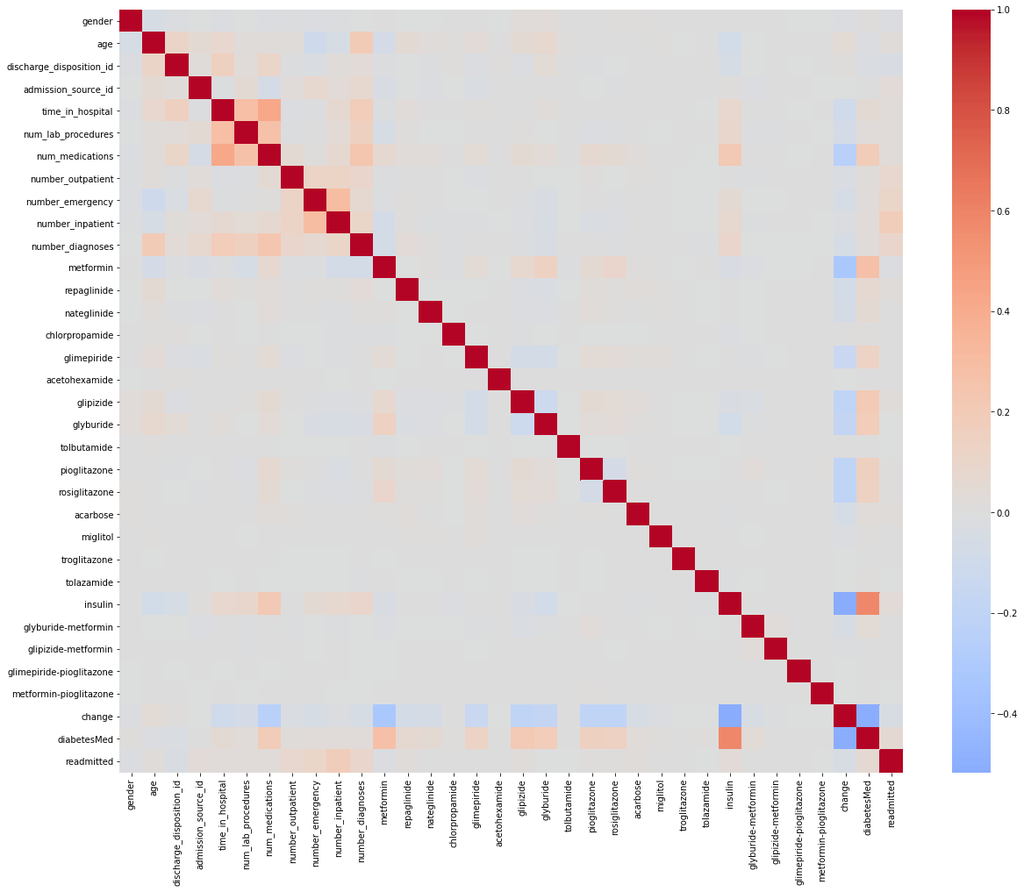

```python
matrix = data.iloc[:, :34].corr()
plt.figure(figsize=(20, 16))
sns.heatmap(matrix, cmap = 'coolwarm', center = .0)

plt.show()
```

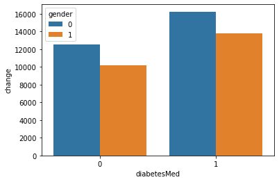

```python
x = pd.DataFrame(data.groupby(by = ["diabetesMed", "gender"], as_index=False)["change"].agg("sum"))
sns.barplot(data = x, x = "diabetesMed", y = "change", hue = "gender")
plt.show()
```

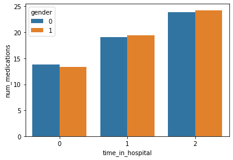

```python
x = pd.DataFrame(data.groupby(by = ["time_in_hospital", "gender"], as_index=False)["num_medications"].agg("mean"))
sns.barplot(data = x, x = "time_in_hospital", y = "num_medications", hue = "gender")
plt.show()
```

Z wykresu można wywnioskować, że często razem z długością pobytu w szpitalu, rośnie też ilość przyjętych przez pacjenta rodzajów leków, co wydaje się dość logiczne. Widać też, że i tym razem płeć nie ma wielkiego znaczenia przy którejkolwiek z tych danych.

Przypomnijmy oznaczenia zmiennej `time_in_hospital`:

- `0 - short`
- `1 - medium`
- `2 - long`

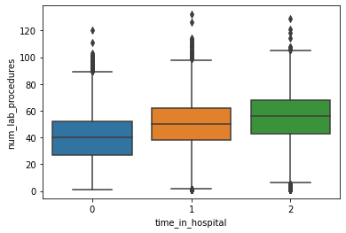

```python
sns.boxplot(data = data, x = "time_in_hospital", y = "num_lab_procedures")
plt.show()
```